# Homework: numerical linear algebra and stability issues

# Problem 1: Kriging / Gaussian process regression

## Part 1: Finishing unfinished business from lecture

Execute a command `git grep -n "sq_exp_cov <- function"` from the root directory of the git repository. Paste the output below.

```r
# Paste the `git grep` output.
homework/numerical_stability.Rmd:23:Execute a command `git grep -n "sq_exp_cov <- function"` from the root directory of the git repository.
lecture/finite_prec_and_numerical_stability.Rmd:276:sq_exp_cov <- function(dist, range) {
lecture/finite_prec_and_numerical_stability.Rmd:303:sq_exp_cov <- function(dist, range) {
```

The grep output tells you where you can find the (failed) kriging / Gaussian process regression example in the lecture source file. Copy the synthetic observation from there (the one defined on the range $[0, 0.4]$ and $[0.6, 1.0]$).

```r
sq_exp_cov <- function(dist, range) {
  return(exp(-(dist / range)^2))
}

loc_obs <- c(seq(0, .4, .01), seq(.6, 1, .01))
n_obs <- length(loc_obs)

set.seed(2021)
corr_range <- .2
dist_obs <- as.matrix(dist(loc_obs))
Sigma_obs <- sq_exp_cov(dist_obs, corr_range)
y_obs <- mvrnorm(mu = rep(0, n_obs), Sigma = Sigma_obs)
```

```r
loc_new <- seq(.41, .59, .01)
# Compute the conditional mean of GP on the new locations.
gauss_conditional_mean <- function(y_2, mu_1, mu_2, cov_12, cov_22) {
  eigen_decomp = eigen(cov_22)
  eigen_vec = eigen_decomp$vectors
  eigen_val = eigen_decomp$values
  # get k
  var_cum = cumsum(eigen_val)/sum(eigen_val)
  k = min(which(var_cum > 1 - 1e-5))
  # compute sigma^-1
  sigma_inv = Reduce('+', lapply(1:k, function(i) {
    (eigen_val[i]^-1*(eigen_vec[, i] %*% t(eigen_vec[, i])))
  }))

  return(mu_1 + cov_12 %*% sigma_inv %*% (y_2 - mu_2))
}

n_new <- length(loc_new)

# mean
mean_obs <- rep(0, n_obs)
mean_new <- rep(0, n_new)

# variance matrix
dist_new <- as.matrix(dist(loc_new))
Sigma_new <- sq_exp_cov(dist_new, corr_range)

# covariance matrix
cross_dist <- as.matrix(dist(c(loc_new, loc_obs)))
cross_dist <- cross_dist[1:n_new, (n_new + 1):(n_new + n_obs)]
Sigma_cross <- sq_exp_cov(cross_dist, corr_range)

# predict
y_pred <- gauss_conditional_mean(y_obs, mean_new, mean_obs, Sigma_cross, Sigma_obs)
```

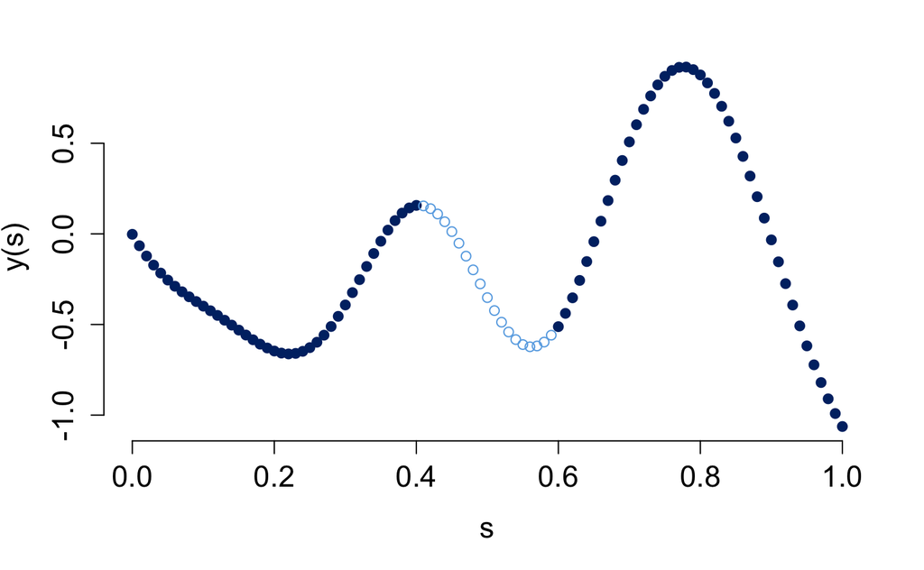

```r
solid_circle_index <- 19
plot(
  loc_obs, y_obs,
  xlab="s", ylab="y(s)",
  pch=solid_circle_index,
  cex.lab=1.4, cex.axis=1.4,
  col=jhu_color$heritageBlue,
  frame.plot = F
)
points(
  loc_new, y_pred,
  col = jhu_color$spiritBlue
)
```

## Part 2: Quantifying uncertainty in interpolation

Use the eigen-decomposition technique to compute the conditional covariance
$$\textrm{Var}(\boldsymbol{y}_1 \, | \, \boldsymbol{y}_2)
= \boldsymbol{\Sigma}_{11} - \boldsymbol{\Sigma}_{12} \boldsymbol{\Sigma}_{22}^{-1} \boldsymbol{\Sigma}_{21},$$
calculate 95% CI intervals of the interpolation, and plot them.

```r
# compute 95% CI
eigen_decomp = eigen(Sigma_obs)
eigen_vec = eigen_decomp$vectors
eigen_val = eigen_decomp$values
var_cum = cumsum(eigen_val)/sum(eigen_val)
k = min(which(var_cum > .9999))
sigma_inv = Reduce('+', lapply(1:k, function(i) {
  (eigen_val[i]^-1*(eigen_vec[, i] %*% t(eigen_vec[, i])))
}))
var_pred <- Sigma_new - Sigma_cross %*% sigma_inv %*% t(Sigma_cross)
ci_lower <- y_pred - 1.96*sqrt(diag(var_pred))
ci_upper <- y_pred + 1.96*sqrt(diag(var_pred))
```

```r
# Plot
plot(
  loc_obs, y_obs,
  xlab="s", ylab="y(s)",
  pch=solid_circle_index,
  cex.lab=1.4, cex.axis=1.4,
  col=jhu_color$heritageBlue,
  frame.plot = F
)
points(
  loc_new, y_pred,
  col = jhu_color$spiritBlue
)
```

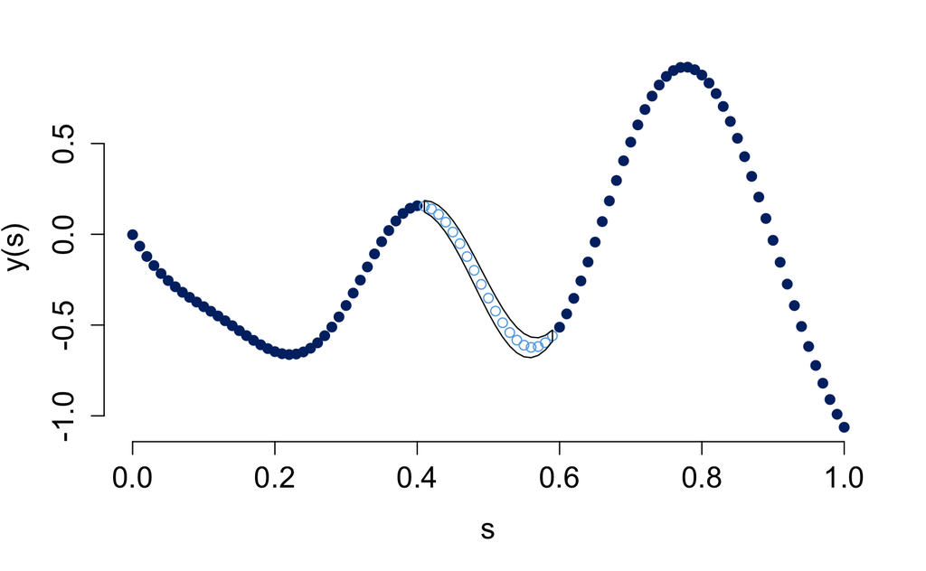

```r
polygon(
  c(rev(loc_new), loc_new),
  c(rev(ci_lower), ci_upper))
```

## Part 3: Kriging based on an alternative GP covariance function

Albeit popular in certain fields, GP based on squared exponential covariance function is often considered “too smooth” for many applications. In particular, its smoothness is partially responsible for the extreme ill-conditioning of its covariance matrix. Here we try carrying out the same interpolation task instead using a *Matern* covariance function.

First find the definition and implementation of a Matern covariance using a command `git grep -n "Matern"`.

```r
homework/numerical_stability.Rmd:75:Here we try carrying out the same interpolation task instead using a _Matern_ covariance function.
homework/numerical_stability.Rmd:77:First find the definition and implementation of a Matern covariance using a command `git grep -n "Matern"`.
lecture/finite_prec_and_numerical_stability.Rmd:255:<!-- Matern covariance with smoothness $\nu = 5/2$: -->
lecture/iterative_method_brief_tour.Rmd:197:<img src="figure/inla_gmrf_approximatin.png" alt="Markovian approximation of Matern field" class="center" style="width: 80%;"/>
```

```r
# Definition of the `matern_cov` function.
matern_cov <- function(dist, range) {
  scaled_dist <- dist / range
  return(
    (1 + sqrt(5) * scaled_dist + 5 / 3 * scaled_dist^2)
    * exp(- sqrt(5) * scaled_dist)
  )
}
```

Then use the eigen decomposition technique as before for interpolation and uncertainty quantification. Afterward, check the condition number of $\boldsymbol{\Sigma}_{\textrm{obs}}$ and see if you can directly compute $\boldsymbol{\Sigma}_{\textrm{obs}}^{-1} \boldsymbol{y}_{\textrm{obs}}$ using the `solve` function. Do we get the same answer as the one based on eigen decomposition?

```r
set.seed(2021)
Sigma_obs <- matern_cov(dist_obs, corr_range)
y_obs <- mvrnorm(mu = mean_obs, Sigma = Sigma_obs)

eigen_decomp = eigen(Sigma_obs)
eigen_vec = eigen_decomp$vectors
eigen_val = eigen_decomp$values
var_cum = cumsum(eigen_val)/sum(eigen_val)
k = min(which(var_cum > .9999))
sigma_inv = Reduce('+', lapply(1:k, function(i) {
  (eigen_val[i]^-1*(eigen_vec[, i] %*% t(eigen_vec[, i])))
}))

Sigma_new <- matern_cov(dist_new, corr_range)
Sigma_cross <- matern_cov(cross_dist,  corr_range)
y_pred <- mean_new + Sigma_cross %*% (sigma_inv %*% (y_obs - mean_obs))
var_pred <- Sigma_new - Sigma_cross %*% sigma_inv %*% t(Sigma_cross)
ci_lower <- y_pred - 1.96*sqrt(diag(var_pred))
ci_upper <- y_pred + 1.96*sqrt(diag(var_pred))

y_pred_solve <- mean_new + Sigma_cross %*% solve(Sigma_obs, y_obs - mean_obs)
var_pred_solve <-  Sigma_new - Sigma_cross %*% solve(Sigma_obs) %*% t(Sigma_cross)
ci_lower_solve <- y_pred_solve - 1.96*sqrt(diag(var_pred_solve))
ci_upper_solve <- y_pred_solve + 1.96*sqrt(diag(var_pred_solve))
```

```r
# Plot
plot(
  loc_obs, y_obs,
  xlab="s", ylab="y(s)",
  pch=solid_circle_index,
  cex.lab=1.4, cex.axis=1.4,
  col=jhu_color$heritageBlue,
  frame.plot = F,
  ylim = c(-3, 2)
)
points(loc_new, y_pred, col = jhu_color$spiritBlue)
```

```r
lines(loc_new, ci_lower, col = jhu_color$spiritBlue)
lines(loc_new, ci_upper, col = jhu_color$spiritBlue)
```

```r
points(loc_new, y_pred_solve, col = jhu_color$orange)
lines(loc_new, ci_lower_solve, col = jhu_color$orange)
```

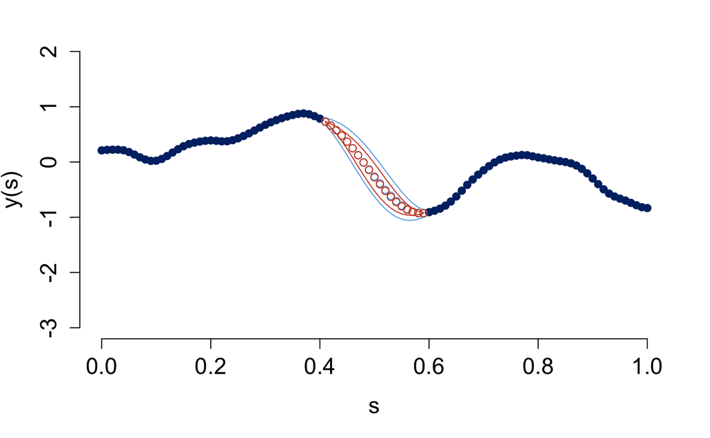

```r
lines(loc_new, ci_upper_solve, col = jhu_color$orange)
```

**Bonus question:** Symmetric positive-definite matrices can be inverted more quickly via the *Cholesky decomposition* $\boldsymbol{L} \boldsymbol{L}^\intercal = \boldsymbol{A}$ than via the LU or QR decomposition. The Cholesky decomposition also provides the “sqrt” of covariance matrix you need to sample from multivariate Gaussians. (Though you might be stuck with the eigen decomposition technique if the matrix is ill-conditioned.) Try computing $\boldsymbol{\Sigma}_{\textrm{obs}}^{-1} \boldsymbol{y}_{\textrm{obs}}$ via `chol` and `forward/backsolve`.